# Practicum for Session 2 of R workshop for Incoming GCB Students (2019)

By: Amy Campbell

## Introduction

In this practicum, we’ll put the data manipulation and visualization practices we’ve talked about to use. Things we want you to try to do are written in **red**. If you have a package installed, you can call **help()** on any of its functions to get any documentation associated with them. If that documentation isn’t useful, try looking at online documentation:

- https://ggplot2.tidyverse.org/
- https://dplyr.tidyverse.org/
- https://cran.r-project.org/web/packages/RColorBrewer/index.html

Functions that will prove useful: **base R**

- summary()
- as.factor()

**ggplot2**

- ggplot()
- facet_grid()
- ggtitle()
- scale_color_manual()
- scale_fill_manual()
- qplot()
- geom_boxplot()
- geom_histogram()
- geom_bar()
- theme()
- labs()

**dplyr**

- group_by()
- mutate()
- filter()
- %>%
- arrange()
- ifelse()
- case_when()

Packages you should be sure to install using **install.packages()**:

- RColorBrewer
- dplyr
- ggplot2

Remember, you can access one variable in a dataframe using **$**.

## The dataset

The data we’ll be using are from city-provided reports of energy & natural resource usage by large buildings in Philadelphia, accessed via https://www.opendataphilly.org/dataset/large-commercial-building-energy-benchmarking . For simplicity, we’ve subsetted the data to 10 zip codes and to 5 collapsed categories for property type(for full data pre-processing, you can (optionally) look at github:gcb-r-workshop/session2/Practicum/formatting_energy.R)

The dataframe is stored in a comma-separated text file, and its filename is *city_energy_data.csv*. Rows represent properties and columns represent different variables. The first row of the file contains the variable names (‘header’)

**1.)**

**Read the file in and save it as a variable called ‘energy’**

**3.)**

**Try to use ggplot2 to make a histogram of square footage.**

**Hint:** Rememember that making a plot with ggplot2 usually requires adding your chart type to an initial ggplot(dataframe, aes(x=?, y=?, fill=?)) instance. If it’s hard to see the distribution with a histogram of raw values, try using a transformation like log() or log10(), and try changing the geom_histogram(bins=???) variable– Make sure to include a title!

**4.)**

Note that if you just use the default geom_histogram() call, you’ll get a gray background with darker grey bars. If you want, **try selecting the fill color by looking up color keys, or by setting a palette using RColorBrewer.** Here’s a list of RColorBrewer palettes. You can get an ordered list of values corresponding to the first ‘n’ colors in one of these palettes using RColorBrewer::brewer.pal( “”). In geom_histogram(), ‘color’ sets the color of the bar outlines, and ‘fill’ sets the color filling the bars.

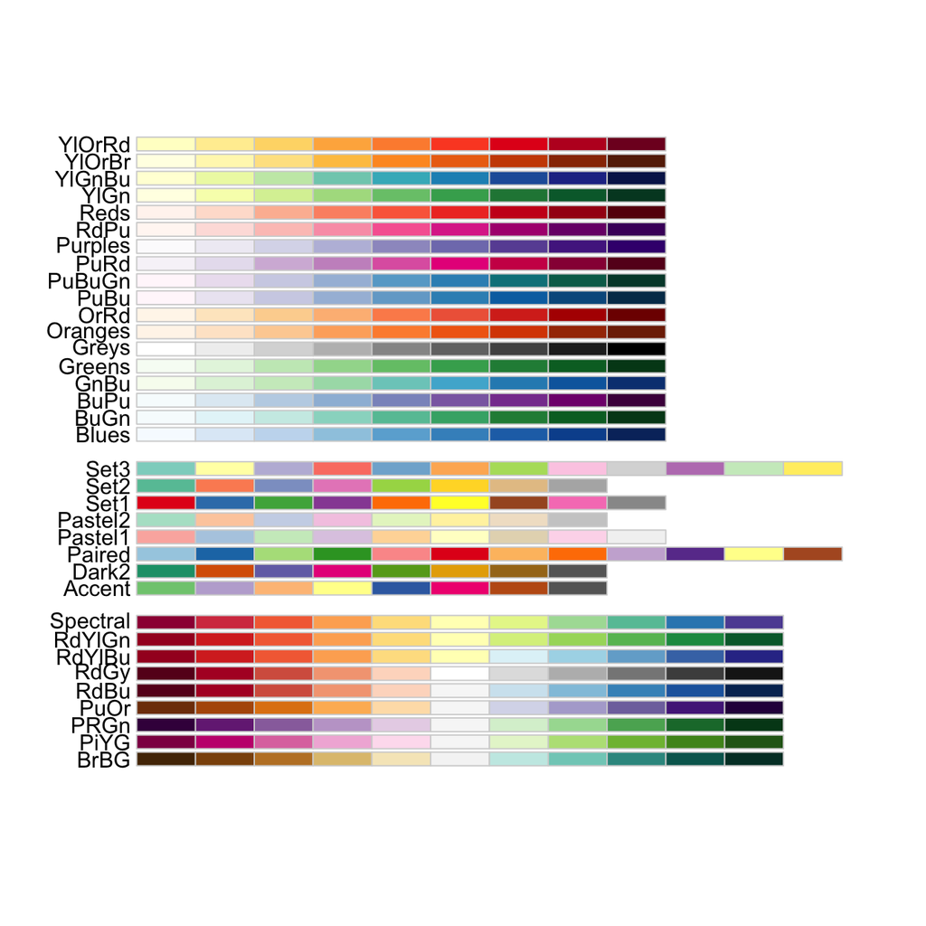

```r
RColorBrewer::display.brewer.all()
```

**5.)**

It’s not normally distributed, but it seems like log-scaled axes will help us see any patterns in this variable more easily. **Next, make the same plots but for the greenhouse_emissions variable.**

**6.)**

**Next, make a scatterplot of greenhouse_emissions vs. squarefootage.**. It can be a simple one for now, but use ggplot2’s scatterplot function geom_point(). Remember what you saw in the above histograms when you’re choosing how to plot this.

**7.)**

Now, let’s consider whether this trend is the same across the years the buildings were constructed. First, we’ll make a new factor in the **energy** dataframe coded by the range of years a property was built in. Just so our ‘facets’ are evenly distributed, we’ll divide them into year_built quartiles based on the results of our summary(energy$year_built) call. **year_built** by **Add a variable to the dataframe called “year_range” that splits year_built into the following groups: 1756-1927 ; 1928-1968; 1969-1994; 1994-2017.**. **Hint**: One way to do this is to use dplyr’s **mutate** with the ifelse() statement, but you might find **case_when()** to be cleaner. You might want to ignore properties without recorded year_built (is.na(year_built)). Save this new dataframe as a new dataframe called **energy_updated**.

**8.)**

Now that we have the **year_range** variable, we can use it to split the previous scatterplot into 4 side-by-side plots of different building periods. **Use the year_range variable to plot greenhouse_emissions against squarefootage as 4 side-by-side scatterplots separated by year_built.*. In case you don’t have a favorite color palette, here’s one you can use with scale_color_manual(values=c()): cbm_palette <- c(“#9900FF”,“#FF9900”, “#0072B2”, “#33CC33”, “#663300”, “#CC99FF”, “#F0E442”, “#4D4D4D”, “#CC0000”, “#006600”, “#D119A3”, “#56B4E9”)

**9.)**

Now, let’s look at another metric of energy/resource use in the city. **Make a histogram of the water_use variable, applying any transformations you think might be useful**

**10.)**

Now, let’s compare average water usage by zipcode (postal_code) using side-by-side boxplots. **geom_boxplot()** is the extension of ggplot you’ll need for this. Try to color the boxplots by zip code. **Hint**: You may have to convert **postal_code** to a factor from an integer variable.

**11.)**

Finally, let’s practice making stacked bar charts. In this step, we’ll look at how many observations of each **property_type** we have. To make things a little more interesting, we’ll fill the bars for each type by the zipcode the buildings are found in. You can make a bar chart using geom_bar(), and can make this a “stacked” barchart using **aes(fill= )**. **Make a stacked barplot of # properties by postal code**

[output not shown]